# SQUAREM for Normal Topic Model in RNA-Seq Data

Kushal Kumar Dey

Tuesday, March 03, 2015

We present here the most basic of our RNA-Seq admixture based clustering techniques, where we assume that the data is normally distributed. For instance, we may normalize the reads data in RNA-Seq to find RPKM (Reads per kilo base per million) which when $log_2$ transformed, could be assumed to be approximately normally distributed. Also in Mehylation assays, we usually have the signals $M$ and $U$ corresponding to methylated and unmethylated site for each CpG site. Now, instead of finding the beta value $\beta=\frac{M}{M+U}$, we may as well find the quantity $log_2 (\frac{M}{U})$ for which the variance is not dependent on $\mu$. This quantity can again be considered to be following a Normal distribution.

We shall proceed in the same way, first depicting the simulation set up, with parameters and hyperparameters user defined.

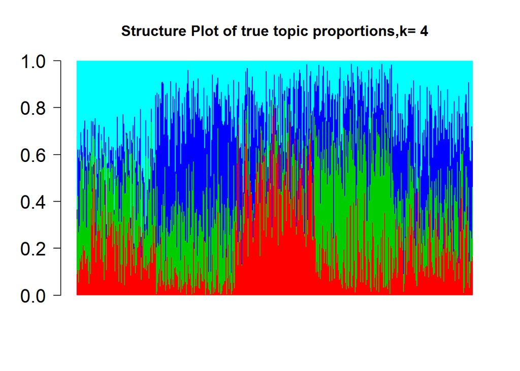

```r
############   Normal  Topic Model without Random Effect  ####################

###  We have solved the problem of normal topic model, now we introduce a random

###  effect in the normal topic model and see how the methods work.  We shall

###  focus on the case with a single rando effect in the model


##################   Set  up 1   for Counts  Table  ########################
K=4;
G=100;
N=500;

alpha_true=matrix(rnorm((K)*G,0.5,1),nrow=(K)); ### the matrix of fixed effects

Label.Batch=c(rep(1,N/4),rep(2,N/4),rep(3,N/4),rep(4,N/4));

B=max(Label.Batch);

sigmab_true=0;

beta_true=matrix(0,B,G);       ###  the matrix of the random effect

for(g in 1:G)
{
  beta_true[,g]=rnorm(B,mean=0,sd=sigmab_true);
}

library(gtools)
T=10;
omega_true=matrix(rbind(rdirichlet(T*10,c(3,4,2,6)),rdirichlet(T*10,c(1,4,6,3)),
            rdirichlet(T*10,c(4,1,2,2)),rdirichlet(T*10,c(2,6,3,2)),
            rdirichlet(T*10,c(3,3,5,4))), nrow=N);


H_true=alpha_true

###  generating the table

read_counts=matrix(0,N,G);

for(n in 1:N)
{
    read_counts[n,]=omega_true[n,]%*%H_true +0*rnorm(G,0,1);
}

windows()
k=K
barplot(t(omega_true),col=2:(k+1),axisnames=F,space=0,border=NA,main="",las=1,ylim=c(0,1),cex.axis=1.5,cex.main=1.4)
title(main=paste("Structure Plot of true topic proportions,k=",K))
```

```r
 reverse_transform=function(x)
  {
    out=array(0,K-1);
        for(i in 1:(K-1))
        {
            out[i]=log((x[i]+10^(-5))/(x[K]+10^(-5)));
        }
        return(out)
    }

# Data


    # Log-Likelihood
    loglik_norm <- function(u,y,x) sum((y - x %*% u)^2)

    # Transform the parameters: we just have
    # to find a bijection between R^3
    # and {(a,b,c,d) \in [0,1]^4 : a+b+c+d=1}.

  transform <- function(v)
  {
    # Ensure they in [0,1]
    temp =c(exp(v),1);
    out=temp/(1+sum(exp(v)));
    return(out)
    }
```

Given this, we now proceed to the main step, where we use an iterative algorithm to get the estimates of the topic proportion parameters $\omega$ and the effect size $\alpha$. To speed up this iterative process, we use the **SQUAREM** approach.

```r
#############  SQUAREM  for Normal Topic Model (No Random effect) #############

counts=read_counts;
N=dim(counts)[1];  G=dim(counts)[2];
y=matrix(counts,1,N*G);

scale=1; K=4;

require("setRNG")
```

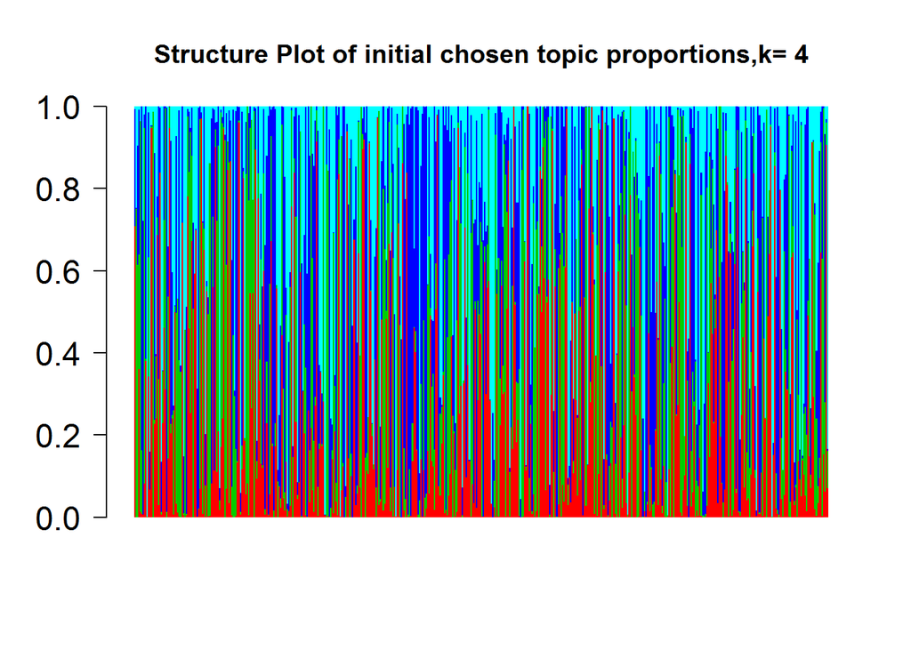

```r
old.seed <- setRNG(list(kind="Mersenne-Twister", normal.kind="Inversion",
seed=54321))


omega0=matrix(rdirichlet(N,c(scale/K,scale/K,scale/K,scale/K)), nrow=N);
alpha0=matrix(rnorm((K)*G,1,1),nrow=(K)); ### the matrix of fixed effects

windows()
k=K
barplot(t(omega0),col=2:(k+1),axisnames=F,space=0,border=NA,main="",las=1,ylim=c(0,1),cex.axis=1.5,cex.main=1.4)
title(main=paste("Structure Plot of initial chosen topic proportions,k=",K))
```

```r
param0=c(matrix(omega0,1,N*K),matrix(alpha0,1,K*G));

library(SQUAREM)

normal_topic <-function(param_vec,y)
{
  counts=matrix(y,N,G);
    omega0=matrix(param_vec[1:(N*K)],N,K);
    alpha0=matrix(param_vec[-(1:(N*K))],K,G);

###########   Estimating the effect size alpha  ########################

    svd_omega=svd(omega0);
    temp1=t(svd_omega$v)%*%diag(1/svd_omega$d^2,dim(omega0)[2])%*%svd_omega$v;
    temp2=t(omega0)%*%counts;
    temp1=solve(t(omega0)%*%omega0);
    alpha = temp1%*%temp2;

###########  Estimating the topic proportions ########################


    omega=matrix(0,dim(counts)[1],K);
    for(n in 1:dim(counts)[1])
    {
        omega_vec=omega0[n,];
        counts_vec=counts[n,];
        res=optim(reverse_transform(omega_vec), function(v) loglik_norm(transform(v),counts_vec,t(alpha)) );
        omega[n,]=transform(res$par);
    }

    param_vec_omega=matrix(omega,1,N*K);
    param_vec_alpha=matrix(alpha,1,K*G);
    param_new_vec=c(param_vec_omega,param_vec_alpha);
    param_vec=param_new_vec
    return(param_new_vec)
}

options(warn=-1)
system.time(res <- squarem(p=param0,y=y, fixptfn=normal_topic, control=list(maxiter = 100, trace = FALSE)));
```

```
##    user  system elapsed
##   57.17    0.08   58.35
```

```r
omega_final=matrix(res$par[1:(N*K)],N,K);
alpha_final=matrix(res$par[-(1:(N*K))],K,G)


docweights=omega_final;
library(permute);
library("BioPhysConnectoR");
```

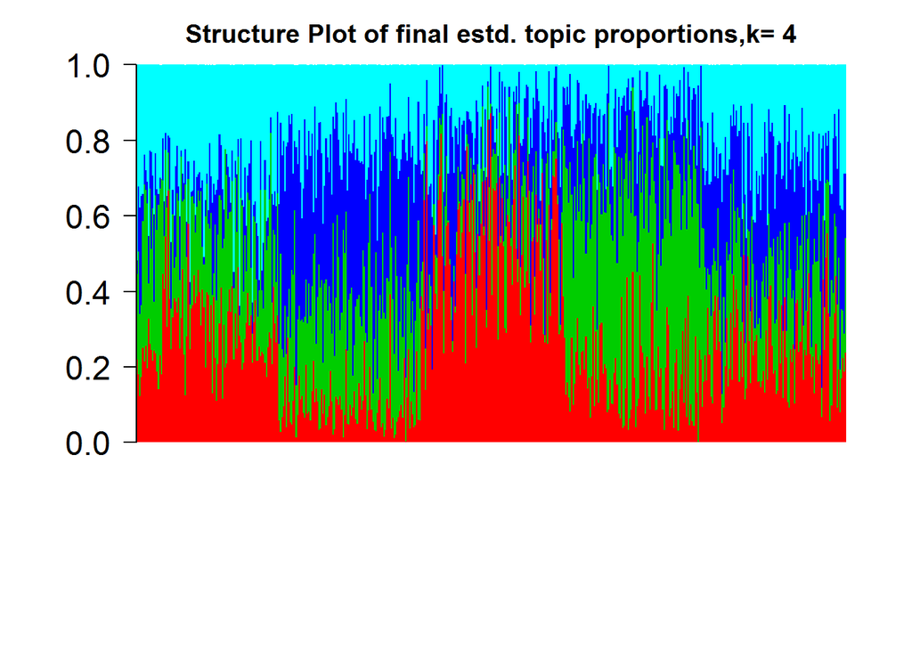

```r
perm_set=rbind(1:K,allPerms(1:K));
diff=array(0,dim(perm_set)[1]);
for (p in 1:dim(perm_set)[1])
{
    temp=docweights[,perm_set[p,]];
    diff[p]=fnorm(temp,omega_true);
}

p_star=which(diff==min(diff));
docweights=docweights[,perm_set[p_star,]];

omega_final=docweights;
alpha_final=alpha_final[perm_set[p_star,],];


windows()
par(mar=c(8,5.25,2.5,2.5))

# - get rid of space space between leftmost bar and y axis
par(xaxs="i")

k=K
# Make plot
# - plot data
barplot(t(omega_final),col=2:(k+1),axisnames=F,space=0,border=NA,main="",las=1,ylim=c(0,1),cex.axis=1.5,cex.main=1.4)
title(main=paste("Structure Plot of final estd. topic proportions,k=",K))
```